# DS_Math_Week_5_Final_Daniel_Thonn

8/9/15

## Assignment DS-Math Homework-5: Final Project

Load the hflights package

```r
#install.packages("hflights")
#install.packages("ggplot2")
#install.packages("pastecs")
#install.packages("chron")
library(hflights)
library(ggplot2)
library(chron)
```

Explore the hflights package

```r
library(hflights)

head(hflights)
```

```
##      Year Month DayofMonth DayOfWeek DepTime ArrTime UniqueCarrier
## 5424 2011     1          1         6    1400    1500            AA
## 5425 2011     1          2         7    1401    1501            AA
## 5426 2011     1          3         1    1352    1502            AA
## 5427 2011     1          4         2    1403    1513            AA
## 5428 2011     1          5         3    1405    1507            AA
## 5429 2011     1          6         4    1359    1503            AA
##      FlightNum TailNum ActualElapsedTime AirTime ArrDelay DepDelay Origin
## 5424       428  N576AA                60      40      -10        0    IAH
## 5425       428  N557AA                60      45       -9        1    IAH
## 5426       428  N541AA                70      48       -8       -8    IAH
## 5427       428  N403AA                70      39        3        3    IAH
## 5428       428  N492AA                62      44       -3        5    IAH
## 5429       428  N262AA                64      45       -7       -1    IAH
##      Dest Distance TaxiIn TaxiOut Cancelled CancellationCode Diverted
## 5424  DFW      224      7      13         0                         0
## 5425  DFW      224      6       9         0                         0
## 5426  DFW      224      5      17         0                         0
## 5427  DFW      224      9      22         0                         0
## 5428  DFW      224      9       9         0                         0
## 5429  DFW      224      6      13         0                         0
```

```r
names(hflights)
```

```
##  [1] "Year"              "Month"             "DayofMonth"
##  [4] "DayOfWeek"         "DepTime"           "ArrTime"
##  [7] "UniqueCarrier"     "FlightNum"         "TailNum"
## [10] "ActualElapsedTime" "AirTime"           "ArrDelay"
## [13] "DepDelay"          "Origin"            "Dest"
## [16] "Distance"          "TaxiIn"            "TaxiOut"
## [19] "Cancelled"         "CancellationCode"  "Diverted"
```

```r
str(hflights)
```

```
## 'data.frame':    227496 obs. of  21 variables:
##  $ Year             : int  2011 2011 2011 2011 2011 2011 2011 2011 2011 2011 ...
##  $ Month            : int  1 1 1 1 1 1 1 1 1 1 ...
##  $ DayofMonth       : int  1 2 3 4 5 6 7 8 9 10 ...
##  $ DayOfWeek        : int  6 7 1 2 3 4 5 6 7 1 ...
##  $ DepTime          : int  1400 1401 1352 1403 1405 1359 1359 1355 1443 1443 ...
##  $ ArrTime          : int  1500 1501 1502 1513 1507 1503 1509 1454 1554 1553 ...
##  $ UniqueCarrier    : chr  "AA" "AA" "AA" "AA" ...
##  $ FlightNum        : int  428 428 428 428 428 428 428 428 428 428 ...
##  $ TailNum          : chr  "N576AA" "N557AA" "N541AA" "N403AA" ...
##  $ ActualElapsedTime: int  60 60 70 70 62 64 70 59 71 70 ...
##  $ AirTime          : int  40 45 48 39 44 45 43 40 41 45 ...
##  $ ArrDelay         : int  -10 -9 -8 3 -3 -7 -1 -16 44 43 ...
##  $ DepDelay         : int  0 1 -8 3 5 -1 -1 -5 43 43 ...
##  $ Origin           : chr  "IAH" "IAH" "IAH" "IAH" ...
##  $ Dest             : chr  "DFW" "DFW" "DFW" "DFW" ...
##  $ Distance         : int  224 224 224 224 224 224 224 224 224 224 ...
##  $ TaxiIn           : int  7 6 5 9 9 6 12 7 8 6 ...
##  $ TaxiOut          : int  13 9 17 22 9 13 15 12 22 19 ...
##  $ Cancelled        : int  0 0 0 0 0 0 0 0 0 0 ...
##  $ CancellationCode : chr  "" "" "" "" ...
##  $ Diverted         : int  0 0 0 0 0 0 0 0 0 0 ...
```

Using the hflights package or another large (greater than 100,000 observations and 20 variables) dataset of your choosing, pick two quantitative variables (e.g., Arrival Delay and Departure Delay). Define one of these variables as the random variable X and the other as the random variable Y. One of these variables must be skewed to the right (positively)

```r
#ArrDelay and DepDelay are in units: minutes
x <- hflights$ArrDelay
y <- hflights$DepDelay
x2 <-hflights$AirTime
y2 <-hflights$Distance
z2 <-hflights$ActualElapsedTime
a2 <-hflights$DepDelay
b2 <-hflights$Diverted
c2 <-hflights$ArrTime
#x
#y

summary(x)
```

```
##    Min. 1st Qu.  Median    Mean 3rd Qu.    Max.    NA's
## -70.000  -8.000   0.000   7.094  11.000 978.000    3622
```

```r
summary(y)
```

```
##    Min. 1st Qu.  Median    Mean 3rd Qu.    Max.    NA's
## -33.000  -3.000   0.000   9.445   9.000 981.000    2905
```

> summary(x) Min. 1st Qu. Median Mean 3rd Qu. Max. NA’s -70.000 -8.000 0.000 7.094 11.000 978.000 3622

> summary(y) Min. 1st Qu. Median Mean 3rd Qu. Max. NA’s -33.000 -3.000 0.000 9.445 9.000 981.000 2905

Note: From above data both x = $ArrDelay and y = $DepDelay are skewed to the right with Mean > Median.

1a). Probability: Calculate as a minimum the below probabilities a through d. Assume the small letter “x” is estimated as the 3d quartile of the X variable, and the small letter “y” is estimated as the 2d quartile of the Y variable. Interpret the meaning of all probabilities. In addition, make a table of counts as shown below.

x= 3rd Qtrl X = 11.0

y = 2nd Qrtl Y = 0

```r
#install.packages("data.table")
library(data.table)

#Build Matrix Table of counts

# a11: x <= 3d ; y <=2d
a11 <- nrow(subset(hflights, x <= 11 & y <= 0))

# a21: x> 3d ; y <=2d
a21 <- nrow(subset(hflights, x > 11 & y <= 0))

# a12: x <= 3d ; y > 2d
a12 <- nrow(subset(hflights, x <= 11 & y > 0))

# a22: x > 3d ; y > 2d
a22 <- nrow(subset(hflights, x > 11 & y > 0))

total_r1 <- a11 + a12
total_r2 <- a21 + a22
total_c1 <- a11 + a21
total_c2 <- a12 + a22
total_all <- total_c1 + total_c2

aa <- c('<=3d quartile', '>3d quartile','Total')
bb <- c(a11,a12,total_r1)
cc <- c(a21,a22,total_r2)
dd <- c(total_c1,total_c2,total_all)
CountTable <- data.frame('x=y'=aa,'LE2d quartile'=bb,'GT2d quartile'=cc,'Total'=dd)
CountTable
```

```
##             x.y LE2d.quartile GT2d.quartile  Total
## 1 <=3d quartile        108141          6159 114300
## 2  >3d quartile         61026         48548 109574
## 3         Total        169167         54707 223874
```

CountTable x.y LE2d.quartile GT2d.quartile Total 1 <=3d quartile 108141 6159 114300 2 >3d quartile 61026 48548 109574 3 Total 169167 54707 223874

```r
#x: 3rd quartile
#y: 2nd quartile


#a: P(X>x | Y>y)
#P(X|Y) <= P(Y|X) * P(X) / Sum (P(Y|X) * P(X))
# P(X given Y)
PXGY1 <- (48548/109574) * (109574/223874) / ((48548/109574)*109574/223874 ) * ((6159/114300)*(114300/223874))
PXGY1
```

```
## [1] 0.02751101
```

```r
#    Answer: > PXGY = [1] 0.02751101

#b:  P(X>x, Y>y)
# P(X and Y) = P(X) + P(Y)
PXAY <- (109574/223874) + (54707/223874)
PXAY
```

```
## [1] 0.7338101
```

```r
# Answer: PXAY =  0.7338101

#c:  P(X<x | Y>y)
#P(X|Y) <= P(Y|X) * P(X) / Sum (P(Y|X) * P(X))
# P(X given Y)
PXGY2 <- (6159/114300) * (114300/223874) / ((6159/114300)*114300/223874 ) * ((48548/109574)*(109574/223874))
PXGY2
```

```
## [1] 0.2168541
```

```r
#Answer=PXGY2 = 0.2168541
```

1b). Does splitting the data in this fashion make them independent? Let A be the new variable counting those observations above the 3d quartile for X, and let B be the new variable counting those observations for the 2d quartile for Y. Does P(A|B)=P(A)P(B)? Check mathematically, and then evaluate by running a Chi Square test for association.

CountTable x.y LE2d.quartile GT2d.quartile Total 1 <=3d quartile 108141 6159 114300 2 >3d quartile 61026 48548 109574 3 Total 169167 54707 223874

```r
#x: 3rd quartile
#y: 2nd quartile
#a: P(X>x | Y<=y)

#Does P(A|B)=P(A)*P(B)?
#Check P(A|B)
#P(X|Y) <= P(Y|X) * P(X) / Sum (P(Y|X) * P(X))
# PXGY = P(A|B) = PAGB1
PAGB1 <- (61026/109574) * (109574/223874) / ((61026/109574)*109574/223874 ) * ((108141/114300)*(114300/223874))
PAGB1
```

```
## [1] 0.483044
```

```r
#PAGB1 = PXGY = 0.483044

#Check P(A) * P(B)
PAGB2 = (109574/223874) * (54707/223874)
PAGB2
```

```
## [1] 0.1196033
```

```r
# PAGB2 =   0.1196033
# Conclusion: PAGB1 <> PAGB2, so events not independent


#Chisquared test
#hypothesis: x and y are independent
chisq.test(x,y)
```

```
##
##  Pearson's Chi-squared test
##
## data:  x and y
## X-squared = 24824000, df = 197270, p-value < 2.2e-16
```

```r
#data:  x and y
#X-squared = 24824000, df = 197270, p-value < 2.2e-16
#Conclusion: p-value is less than .05 signicance level, hypothesis rejected, x and y not independent
```

2). Descriptive and Inferential Statistics: Provide univariate descriptive statistics and appropriate plots. Provide a scatterplot of the two variables. Provide a 95% CI for the difference in the mean of the variables. Derive a correlation matrix for two of the quantitative variables you selected. Test the hypothesis that the correlation between these variables is 0 and provide a 99% confidence interval. Discuss the meaning of your analysis.

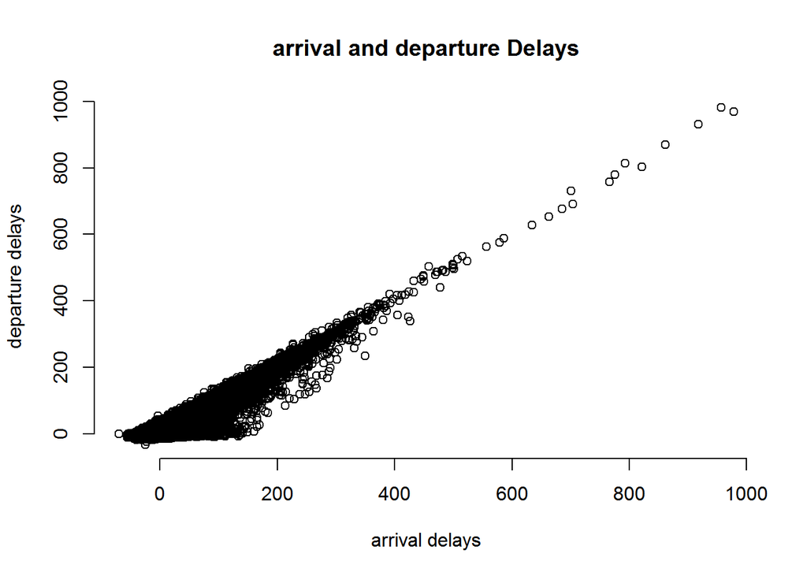

```r
# Scatterplot of two variables

plot(x, y, xlab="arrival delays", ylab="departure delays", main="arrival and departure Delays",frame.plot=FALSE)
```

```r
# 95% Confidence Intervel
t.test(y,x)
```

```
##
##  Welch Two Sample t-test
##
## data:  y and x
## t = 26.436, df = 446450, p-value < 2.2e-16
## alternative hypothesis: true difference in means is not equal to 0
## 95 percent confidence interval:
##  2.176342 2.524892
## sample estimates:
## mean of x mean of y
##  9.444951  7.094334
```

```r
#data:  y and x
#t = 26.436, df = 446450, p-value < 2.2e-16
#alternative hypothesis: true difference in means is not equal to 0
#95 percent confidence interval:
# 2.176342 2.524892
#sample estimates:
#mean of x mean of y
# 9.444951  7.094334

# Correlation Test
cor.test(y,x,conf.level=0.99)
```

```
##
##  Pearson's product-moment correlation
##
## data:  y and x
## t = 1189.8, df = 223870, p-value < 2.2e-16
## alternative hypothesis: true correlation is not equal to 0
## 99 percent confidence interval:
##  0.9284710 0.9299578
## sample estimates:
##       cor
## 0.9292181
```

```r
#   Pearson's product-moment correlation

#data:  y and x
#t = 1189.8, df = 223870, p-value < 2.2e-16
#alternative hypothesis: true correlation is not equal to 0
#99 percent confidence interval:
# 0.9284710 0.9299578
#sample estimates:
#      cor
#0.9292181
```